# SQL

If you have trouble with this part, refer to the beginning of the **model validation lab (3.08)** as a reference.

```python
%load_ext sql
```

```python
%sql postgresql://dsi_student:gastudents@35.196.66.7/datasets
```

## Write a SQL query that displays the number of entries in the `airport` table

```python
%%sql

SELECT COUNT(*) FROM airport
LIMIT 5;
```

[output not shown]

## Write a SQL query that displays the number of airports in each state

```python
%%sql

SELECT state, COUNT(state) FROM airport
GROUP BY state
```

[output not shown]

# Naive Bayes Lab + NLP

Week 6

In this dataset, we will be looking at labeled movie reviews:

> The dataset is comprised of tab-separated files with phrases from the Rotten Tomatoes dataset. The train/test split has been preserved for the purposes of benchmarking, but the sentences have been shuffled from their original order. Each Sentence has been parsed into many phrases by the Stanford parser. Each phrase has a PhraseId. Each sentence has a SentenceId. Phrases that are repeated (such as short/common words) are only included once in the data.

> train.tsv contains the phrases and their associated sentiment labels. We have additionally provided a SentenceId so that you can track which phrases belong to a single sentence. test.tsv contains just phrases. You must assign a sentiment label to each phrase.

This dataset comes from a Kaggle competition, which you can find [here](https://www.kaggle.com/c/sentiment-analysis-on-movie-reviews/data).

```python
import pandas as pd, seaborn as sns, numpy as np, matplotlib.pyplot as plt

from sklearn.feature_extraction.text import CountVectorizer, TfidfTransformer, TfidfVectorizer
from sklearn.model_selection import cross_val_score, learning_curve
from sklearn.metrics import classification_report
from sklearn.naive_bayes import MultinomialNB, BernoulliNB, GaussianNB
from sklearn.pipeline import Pipeline

%matplotlib inline

sns.set_style("darkgrid")
```

## How to use Naive Bayes

There are three types of Naive Bayes classifiers provided by Sklearn: Gaussian, Multinomial, and Bernoulli. Check out the [documentation](http://scikit-learn.org/stable/modules/naive_bayes.html#naive-bayes) as well as the [Wikipedia on Naive Bayes](https://en.wikipedia.org/wiki/Naive_Bayes_classifier#Parameter_estimation_and_event_models) and [this great overview of Naive Bayes](http://blog.hackerearth.com/introduction-naive-bayes-algorithm-codes-python-r) to learn a bit more. It's OK if not all of this makes sense, you'll still be able to complete the lab.

Like the other classifiers we've used from Scikit Learn, these Naive Bayes models have `.fit()` and `.predict()` methods. Below is a very simple code snippet using simulated data to demonstrate how to use Naive Bayes. It's super straighforward!

```python
# This is just made up data.
X = np.array([[-1, -1], [-2, -1], [-3, -2], [1, 1], [2, 1], [3, 2]])
Y = np.array([1, 1, 1, 2, 2, 2])

#Initialize a variable as the Gaussian Naive Bayes classifier and fit it with the data
clf = GaussianNB()
clf.fit(X, Y)

# Predict a the class of a new observation
print(clf.predict([[-0.8, -1]]))
```

```
[1]
```

## Now, we'll start the lab and use real data

```python
train_df = pd.read_table("assets/train.tsv", sep='\t', encoding="utf-8")
```

```python
train_df.head(3)
```

|  | PhraseId | SentenceId | Phrase | Sentiment |
| --- | --- | --- | --- | --- |
| 0 | 1 | 1 | A series of escapades demonstrating the adage ... | 1 |
| 1 | 2 | 1 | A series of escapades demonstrating the adage ... | 2 |
| 2 | 3 | 1 | A series | 2 |

### 1. Explore a list of comment words that occur more than 50x.

Plotting a histogram of some kind might be helpful.

```python
cvt = CountVectorizer()
X_all = cvt.fit_transform(train_df["Phrase"])
```

```python
# convert fit/transformed data to array of word frequency per comment
X_all.toarray()
```

```
array([[0, 0, 0, ..., 0, 0, 0],
       [0, 0, 0, ..., 0, 0, 0],
       [0, 0, 0, ..., 0, 0, 0],
       ...,
       [0, 0, 0, ..., 0, 0, 0],
       [0, 0, 0, ..., 0, 0, 0],
       [0, 0, 0, ..., 0, 0, 0]], dtype=int64)
```

```python
# store the cumulative frequencies in an array
wfreq = X_all.toarray().sum(axis=0)
```

```python
# put words into array

words = cvt.get_feature_names()
```

```python
# shove words and frequencies into an array and turn it into a DataFrame

freqlist = [[words[ii], wfreq[ii]] for ii in range(len(words))]
wordsDF = pd.DataFrame(data=freqlist)
wordsDF.columns = ['word','frequency']
```

```python
# show the 15 most commonly used words

wordsDF.sort_values('frequency',ascending=False)[:15]
```

|  | word | frequency |
| --- | --- | --- |
| 13505 | the | 51633 |
| 9227 | of | 32702 |
| 625 | and | 32177 |
| 13681 | to | 22761 |
| 6785 | in | 13997 |
| 7217 | is | 13476 |
| 13503 | that | 12338 |
| 7229 | it | 11734 |
| 856 | as | 8651 |
| 15008 | with | 7750 |
| 5323 | for | 7553 |
| 7241 | its | 7051 |
| 5111 | film | 6733 |
| 605 | an | 6502 |
| 8791 | movie | 6241 |

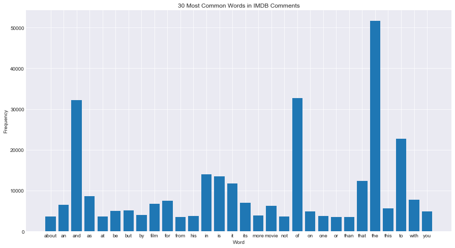

```python
# give a histogram of the 30 most commonly used words, all of which are above 3400 uses

_ = plt.figure(figsize=(15,8))
_ = plt.bar(wordsDF.sort_values('frequency',ascending=False)['word'][:30],wordsDF.sort_values('frequency',ascending=False)['frequency'][:30])
plt.xlabel('Word')
plt.ylabel('Frequency')
plt.title('30 Most Common Words in IMDB Comments')
plt.show()
```

### 1a. Try it again with stopword removal.

```python
cvt = CountVectorizer(stop_words="english")
X_all = cvt.fit_transform(train_df["Phrase"])

# store the cumulative frequencies in an array
wfreq2 = X_all.toarray().sum(axis=0)

# put words into array
words2 = cvt.get_feature_names()

# shove words and frequencies into an array and turn it into a DataFrame
freqlist2 = [[words2[ii], wfreq2[ii]] for ii in range(len(words2))]
wordsDF2 = pd.DataFrame(data=freqlist2)
wordsDF2.columns = ['word','frequency']

# show the 15 most commonly used words
wordsDF2.sort_values('frequency',ascending=False)[:15]
```

|  | word | frequency |
| --- | --- | --- |
| 5026 | film | 6733 |
| 8649 | movie | 6241 |
| 7734 | like | 3190 |
| 12647 | story | 2539 |
| 11202 | rrb | 2438 |
| 5720 | good | 2261 |
| 7917 | lrb | 2098 |
| 13408 | time | 1919 |
| 2135 | characters | 1882 |
| 2532 | comedy | 1813 |
| 7294 | just | 1728 |
| 7711 | life | 1718 |
| 3860 | does | 1674 |
| 7800 | little | 1605 |
| 5443 | funny | 1583 |

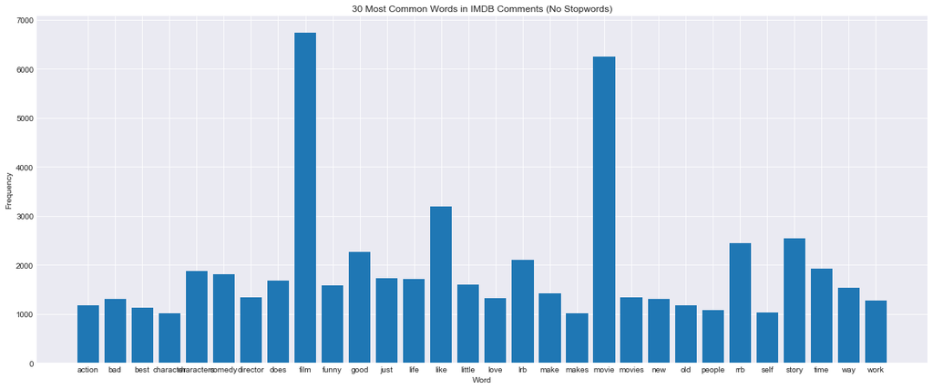

```python
# give a histogram of the 30 most commonly used words

_ = plt.figure(figsize=(20,8))
_ = plt.bar(wordsDF2.sort_values('frequency',ascending=False)['word'][:30],wordsDF2.sort_values('frequency',ascending=False)['frequency'][:30])
plt.xlabel('Word')
plt.ylabel('Frequency')
plt.title('30 Most Common Words in IMDB Comments (No Stopwords)')
plt.show()
```

### 2. Explore ngrams between 2 and 4.

#### ngrams = 2

```python
cvt3 = CountVectorizer(stop_words='english', ngram_range=(2,2))

X_all3 = cvt3.fit_transform(train_df["Phrase"])

# store the cumulative frequencies in an array
wfreq3 = X_all3.toarray().sum(axis=0)
```

```python
# put words into array
words3 = cvt3.get_feature_names()

# shove words and frequencies into an array and turn it into a DataFrame
freqlist3 = [[words3[ii], wfreq3[ii]] for ii in range(len(words3))]
wordsDF3 = pd.DataFrame(data=freqlist3)
wordsDF3.columns = ['word','frequency']

# show the 15 most commonly used phrases
wordsDF3.sort_values('frequency',ascending=False)[:15]
```

|  | word | frequency |
| --- | --- | --- |
| 44435 | romantic comedy | 257 |
| 59348 | year old | 257 |
| 31596 | lrb rrb | 253 |
| 56338 | ve seen | 234 |
| 59148 | writer director | 220 |
| 18254 | feel like | 207 |
| 36256 | new york | 193 |
| 37093 | old fashioned | 190 |
| 49093 | special effects | 184 |
| 48545 | soap opera | 184 |
| 45729 | sci fi | 174 |
| 4468 | big screen | 172 |
| 51010 | subject matter | 171 |
| 44972 | running time | 170 |
| 31311 | love story | 160 |

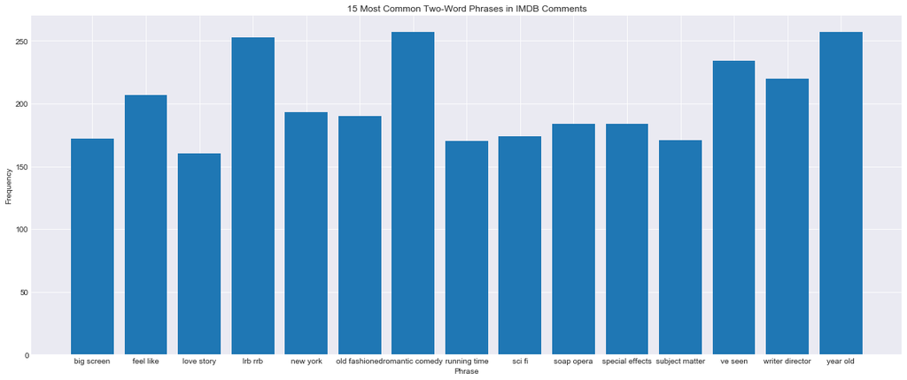

```python
# give a histogram of the 15 most commonly used phrases

_ = plt.figure(figsize=(20,8))
_ = plt.bar(wordsDF3.sort_values('frequency',ascending=False)['word'][:15],wordsDF3.sort_values('frequency',ascending=False)['frequency'][:15])
plt.xlabel('Phrase')
plt.ylabel('Frequency')
plt.title('15 Most Common Two-Word Phrases in IMDB Comments')
plt.show()
```

#### ngrams = 3

```python
cvt4 = CountVectorizer(stop_words='english', ngram_range=(3,3))

X_all4 = cvt4.fit_transform(train_df["Phrase"])

# store the cumulative frequencies in an array
wfreq4 = X_all4.toarray().sum(axis=0)
```

```python
# put words into array
words4 = cvt4.get_feature_names()

# shove words and frequencies into an array and turn it into a DataFrame
freqlist4 = [[words4[ii], wfreq4[ii]] for ii in range(len(words4))]
wordsDF4 = pd.DataFrame(data=freqlist4)
wordsDF4.columns = ['word','frequency']

# show the 15 most commonly used phrases
wordsDF4.sort_values('frequency',ascending=False)[:15]
```

|  | word | frequency |
| --- | --- | --- |
| 56454 | world war ii | 72 |
| 17062 | fat greek wedding | 47 |
| 3691 | beautiful self satisfied | 47 |
| 4263 | big fat greek | 45 |
| 32560 | minute running time | 44 |
| 34969 | new york city | 36 |
| 43589 | saturday night live | 35 |
| 2058 | anne rice novel | 33 |
| 56809 | ya ya sisterhood | 33 |
| 12760 | divine secrets ya | 31 |
| 44426 | secrets ya ya | 31 |
| 40 | 12 year old | 31 |
| 23831 | hour running time | 30 |
| 43612 | saving private ryan | 30 |
| 19786 | french coming age | 30 |

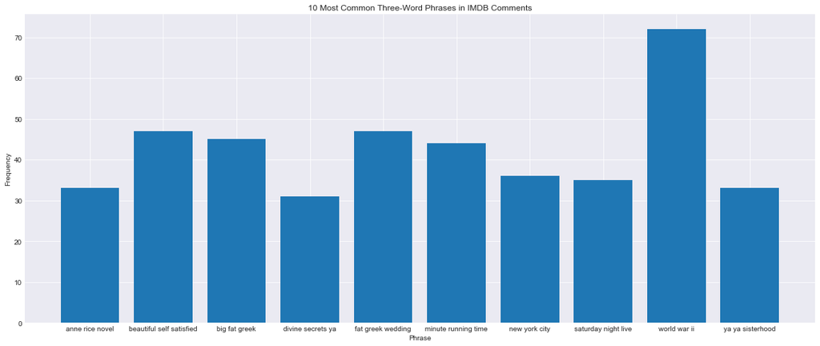

```python
# give a histogram of the 10 most commonly used phrases

_ = plt.figure(figsize=(20,8))
_ = plt.bar(wordsDF4.sort_values('frequency',ascending=False)['word'][:10],wordsDF4.sort_values('frequency',ascending=False)['frequency'][:10])
plt.xlabel('Phrase')
plt.ylabel('Frequency')
plt.title('10 Most Common Three-Word Phrases in IMDB Comments')
plt.show()
```

#### ngrams = 4

```python
cvt5 = CountVectorizer(stop_words='english', ngram_range=(4,4))

X_all5 = cvt5.fit_transform(train_df["Phrase"])

# store the cumulative frequencies in an array
wfreq5 = X_all5.toarray().sum(axis=0)

# put words into array
words5 = cvt5.get_feature_names()

# shove words and frequencies into an array and turn it into a DataFrame
freqlist5 = [[words5[ii], wfreq5[ii]] for ii in range(len(words5))]
wordsDF5 = pd.DataFrame(data=freqlist5)
wordsDF5.columns = ['word','frequency']

# show the 15 most commonly used phrases
wordsDF5.sort_values('frequency',ascending=False)[:15]
```

|  | word | frequency |
| --- | --- | --- |
| 3680 | big fat greek wedding | 45 |
| 11059 | divine secrets ya ya | 31 |
| 38561 | secrets ya ya sisterhood | 30 |
| 129 | 22 year old girlfriend | 26 |
| 37793 | satisfied 22 year old | 25 |
| 38763 | self satisfied 22 year | 25 |
| 25510 | lock stock smoking barrels | 25 |
| 3198 | beautiful self satisfied 22 | 23 |
| 58 | 18 year old mistress | 23 |
| 13244 | equally beautiful self satisfied | 23 |
| 35450 | real dawns comic relief | 23 |
| 3197 | beautiful self satisfied 18 | 22 |
| 44056 | themes loyalty courage dedication | 22 |
| 2945 | ballistic ecks vs sever | 22 |
| 38762 | self satisfied 18 year | 22 |

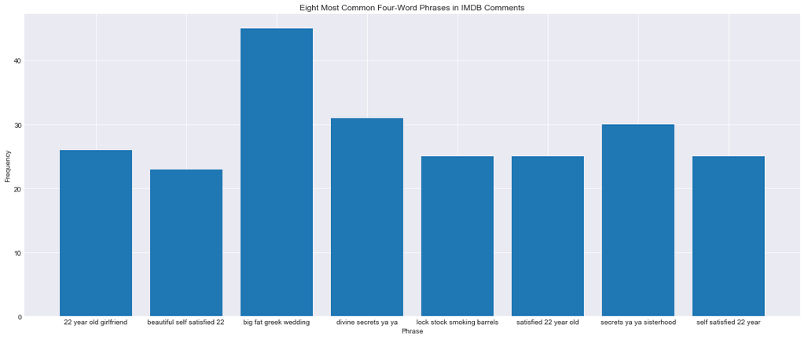

```python
# give a histogram of the 8 most commonly used phrases

_ = plt.figure(figsize=(20,8))
_ = plt.bar(wordsDF5.sort_values('frequency',ascending=False)['word'][:8],wordsDF5.sort_values('frequency',ascending=False)['frequency'][:8])
plt.xlabel('Phrase')
plt.ylabel('Frequency')
plt.title('Eight Most Common Four-Word Phrases in IMDB Comments')
plt.show()
```